# CSA-RQ1

2025-02-12

```r
library(tidyverse)
library(stargazer)
```

```r
library(lubridate)
library(dplyr)
library(tidyr)
library(tibble)
library(ggplot2)
library(stringr)
```

```r
URL1<-"https://raw.githubusercontent.com/ykimasu/PAF540_CSA/refs/heads/main/SIM-2574_emp.csv"
employments<-read_csv(URL1)
view(employments)

URL2<-"https://raw.githubusercontent.com/ykimasu/PAF540_CSA/refs/heads/main/SIM-2574_member_clean.csv"
members<-read_csv(URL2)
view(members)

URL3<-"https://raw.githubusercontent.com/ykimasu/PAF540_CSA/refs/heads/main/SIM-2574_member_clean.csv"
baseline_2017<-read.csv(URL3)
view(baseline_2017)

URL4<-"https://raw.githubusercontent.com/ykimasu/PAF540_CSA/refs/heads/main/SIM-2574_emp_status.csv"
status_changes<-read_csv(URL4)
view(status_changes)

URL5<-"https://raw.githubusercontent.com/ykimasu/PAF540_CSA/refs/heads/main/SIM-2574_salary_clean.csv"
salary<-read.csv(URL5)

URL6<-"https://raw.githubusercontent.com/ykimasu/PAF540_CSA/refs/heads/main/SIM-2574_status_ref.csv"
status_ref<-read.csv(URL6)

URL7<-"https://raw.githubusercontent.com/ykimasu/PAF540_CSA/refs/heads/main/SIM-2574-%20Employer%20Characteristics.csv"
employer_character<-read_csv(URL7)
```

Group member: Ernamia Maria, Maria Garcia Munoz, Olivia Glaser, Umbu Domu Mahani, Yosta Rambu Lika Enga

RQ1 b.

```r
df <- employments %>%
  left_join(members, by = "m_id") %>%
  mutate(age = 2025 - birth_dt) %>%  # Calculate age
  filter(!is.na(age))  # Remove missing age values
```

```r
# Categorize employees into 5 age groups
df <- df %>%

  mutate(age = 2025 - birth_dt,
         hire_year = year(hire_dt),
         age_group = case_when(
           age < 30 ~ "Under 30",
           age >= 30 & age < 40 ~ "30-39",
           age >= 40 & age < 50 ~ "40-49",
           age >= 50 & age < 60 ~ "50-59",
           age >= 60 ~ "60+"
         ))
```

```r
# Count the number of employees in each age group per year
age_group_trends <- df %>%
  group_by(hire_year, age_group) %>%
  summarise(count = n(), .groups = "drop")
```

```r
# Define colors for better readability
age_colors <- c("Under 30" = "#AEDFF7",  # Light Blue
                "30-39" = "#FFCBA4",  # Soft Orange
                "40-49" = "#B0E57C",  # Light Green
                "50-59" = "#FFB6C1",  # Pastel Pink
                "60+" = "#D4A5FF")  # Soft Purple
```

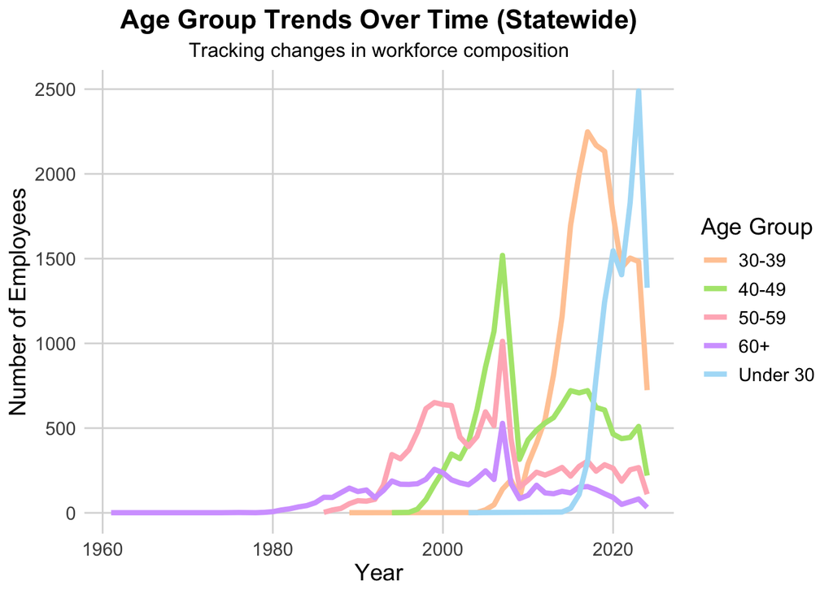

```r
# Create the trend visualization
ggplot(age_group_trends, aes(x = hire_year, y = count, color = age_group, group = age_group)) +
  geom_line(size = 1.5) +
  scale_color_manual(values = age_colors) +
  labs(title = "Age Group Trends Over Time (Statewide)",
       subtitle = "Tracking changes in workforce composition",
       x = "Year",
       y = "Number of Employees",
       color = "Age Group") +
  theme_minimal() +
  theme(text = element_text(size = 14),
        plot.title = element_text(face = "bold", size = 16, hjust = 0.5),
        plot.subtitle = element_text(size = 12, hjust = 0.5),
        panel.grid.major = element_line(color = "gray85"),
        panel.grid.minor = element_blank())
```

Age Trends by Agency

```r
# Count total employees per agency
top_20_agencies <- df %>%
  count(employer_name, name = "total_employees") %>%
  arrange(desc(total_employees)) %>%
  top_n(20, total_employees)  # Get top 20 agencies
```

```r
# Filter the dataset to include only top 20 agencies
df_top20 <- df %>%
  filter(employer_name %in% top_20_agencies$employer_name)
```

```r
# Count employees in each age group per agency
age_group_by_top20 <- df_top20 %>%
  group_by(employer_name, age_group) %>%
  summarise(count = n(), .groups = "drop")
```

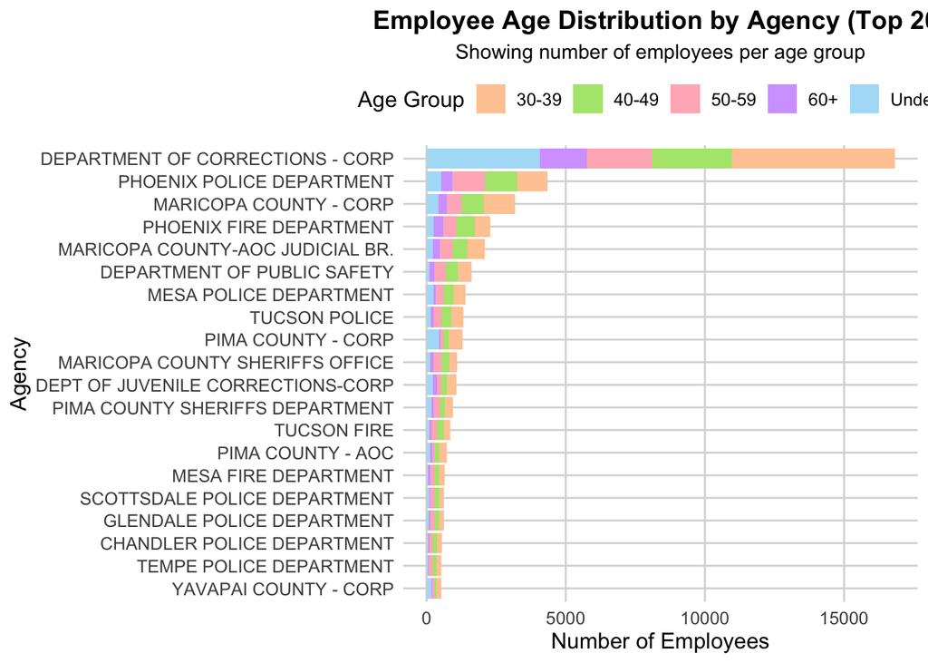

```r
# Define colors for different age groups
age_colors <- c("Under 30" = "#AEDFF7",  # Light Blue
                "30-39" = "#FFCBA4",  # Soft Orange
                "40-49" = "#B0E57C",  # Light Green
                "50-59" = "#FFB6C1",  # Pastel Pink
                "60+" = "#D4A5FF")  # Soft Purple

# Create a stacked horizontal bar chart with labels
ggplot(age_group_by_top20, aes(x = count, y = reorder(employer_name, count), fill = age_group)) +
  geom_col() +
  scale_fill_manual(values = age_colors) +
  labs(title = "Employee Age Distribution by Agency (Top 20)",
       subtitle = "Showing number of employees per age group",
       x = "Number of Employees",
       y = "Agency",
       fill = "Age Group") +
  theme_minimal() +
  theme(text = element_text(size = 12),
        plot.title = element_text(face = "bold", size = 14, hjust = 0.5),
        plot.subtitle = element_text(size = 11, hjust = 0.5),
        legend.position = "top",
        panel.grid.major = element_line(color = "gray85"),
        panel.grid.minor = element_blank())
```

The chart shows that some agencies have a higher concentration of older employees (50+), while others have more younger employees (Under 30 and 30-39). A few agencies have a balanced distribution across all age groups, while others are dominated by either older or younger employees. Agencies with older employees (50+) have a noticeably larger share, while agencies with a strong Under 30 workforce show higher numbers but with variation across agencies. The 30-39 age group appears consistently strong across multiple agencies, while the 40-49 age group varies.

```r
 # Exclude "DEPARTMENT OF CORRECTIONS - CORP" from the dataset
df_filtered <- df %>%
  filter(employer_name != "DEPARTMENT OF CORRECTIONS - CORP")
```

```r
# Count total employees per agency, excluding "DEPARTMENT OF CORRECTIONS - CORP"
top_20_agencies <- df_filtered %>%
  count(employer_name, name = "total_employees") %>%
  arrange(desc(total_employees)) %>%
  top_n(20, total_employees)  # Get top 20 agencies
```

```r
# Filter dataset to include only top 20 agencies
df_top20 <- df_filtered %>%
  filter(employer_name %in% top_20_agencies$employer_name)
```

```r
# Count employees in each age group per agency (excluding the outlier)
age_group_by_top20 <- df_top20 %>%
  group_by(employer_name, age_group) %>%
  summarise(count = n(), .groups = "drop")
```

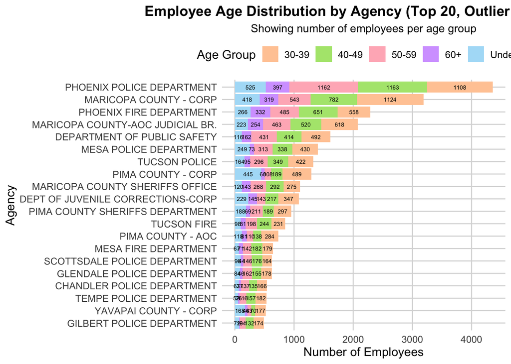

```r
# Define colors for different age groups
age_colors <- c("Under 30" = "#AEDFF7",  # Light Blue
                "30-39" = "#FFCBA4",  # Soft Orange
                "40-49" = "#B0E57C",  # Light Green
                "50-59" = "#FFB6C1",  # Pastel Pink
                "60+" = "#D4A5FF")  # Soft Purple

# Create a stacked horizontal bar chart
ggplot(age_group_by_top20, aes(x = count, y = reorder(employer_name, count), fill = age_group)) +
  geom_col() +
  geom_text(aes(label = count), position = position_stack(vjust = 0.5), size = 2, color = "black") + # Add labels
  scale_fill_manual(values = age_colors) +
  labs(title = "Employee Age Distribution by Agency (Top 20, Outlier Removed)",
       subtitle = "Showing number of employees per age group",
       x = "Number of Employees",
       y = "Agency",
       fill = "Age Group") +
  theme_minimal() +
  theme(text = element_text(size = 12),
        plot.title = element_text(face = "bold", size = 14, hjust = 0.5),
        plot.subtitle = element_text(size = 11, hjust = 0.5),
        legend.position = "top",
        panel.grid.major = element_line(color = "gray85"),
        panel.grid.minor = element_blank())
```

In this chart, We try to eliminate outlier by remove Department of Corrections - COP from to give a more comparable data between agencies.

RQ1 c.

```r
# Ensure total_service is numeric
df <- df %>%
  mutate(total_service = as.numeric(total_service))

# Calculate average years of service per year
service_trends_overall <- df %>%
  group_by(hire_year) %>%
  summarise(avg_service = mean(total_service, na.rm = TRUE)) %>%
  arrange(hire_year)
```

```r
# Calculate average years of service per agency
service_trends_by_agency <- df %>%
  group_by(employer_name) %>%
  summarise(avg_service = mean(total_service, na.rm = TRUE)) %>%
  arrange(desc(avg_service))
```

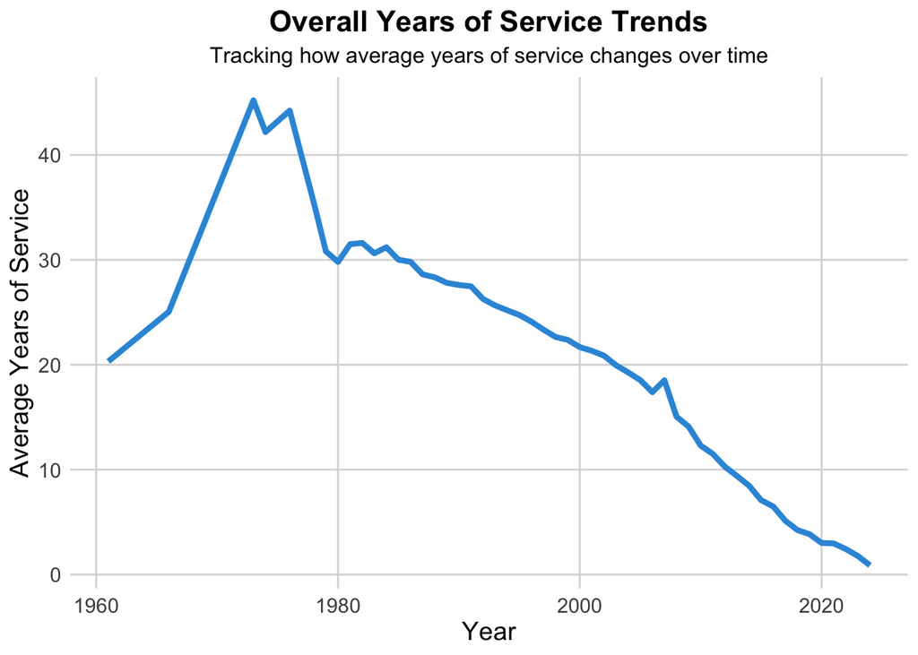

```r
ggplot(service_trends_overall, aes(x = hire_year, y = avg_service)) +
  geom_line(color = "#3498DB", size = 1.5) +
  labs(title = "Overall Years of Service Trends",
       subtitle = "Tracking how average years of service changes over time",
       x = "Year",
       y = "Average Years of Service") +
  theme_minimal() +
  theme(text = element_text(size = 14),
        plot.title = element_text(face = "bold", size = 16, hjust = 0.5),
        plot.subtitle = element_text(size = 12, hjust = 0.5),
        panel.grid.major = element_line(color = "gray85"),
        panel.grid.minor = element_blank())
```

The line chart above shows that the aberage years of service increased sharply after 1960 but experienced a mojor decline around 1980. The highest recorded years of service appear before the decline which means that employees hired in earlier years tended to stay longer. After 2008, the average years of service gradually decreased which showing a possible shift in retention patterns or workforce turnover.

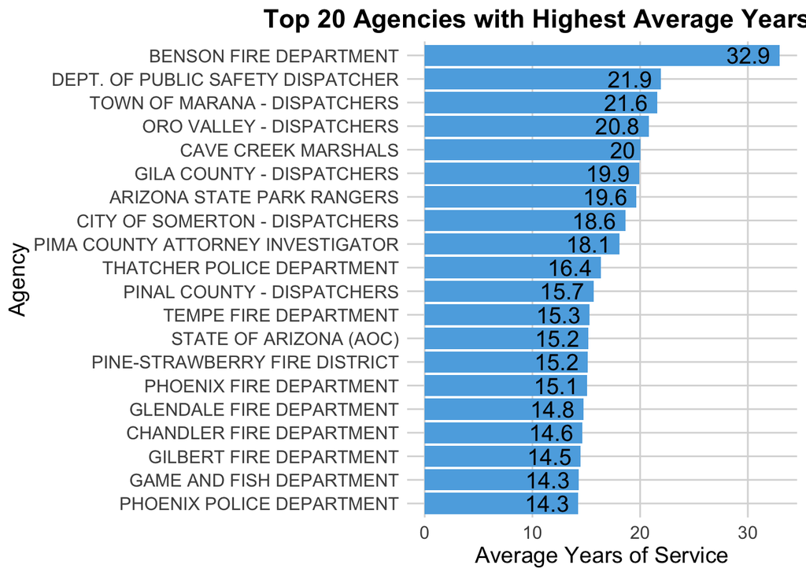

```r
# Select top 20 agencies with highest average service
top_20_agencies_service <- service_trends_by_agency %>% top_n(20, avg_service)

# Create a horizontal bar chart
ggplot(top_20_agencies_service, aes(x = avg_service, y = reorder(employer_name, avg_service))) +
  geom_col(fill = "#5DADE2") +
  geom_text(aes(label = round(avg_service, 1)), hjust = 1.2, color = "black", size = 5) +  # Add labels
  labs(title = "Top 20 Agencies with Highest Average Years of Service",
       x = "Average Years of Service",
       y = "Agency") +
  theme_minimal() +
  theme(text = element_text(size = 14),
        plot.title = element_text(face = "bold", size = 16, hjust = 0.5),
        panel.grid.major = element_line(color = "gray85"),
        panel.grid.minor = element_blank())
```

From the chart above, certain agencies have higher average years of service. This is indicating that employees tend to stay longer in those organizations and also strong retention. Meanhwhile, agencies lower on the list still have relatively high average service years but may have seen more recent hiring or turnover. The difference between agencies shows variations in workforce stability, with some agencies maintaining a more experienced workforce than others.

RQ1 d.

```r
# Ensure hire and termination dates are in Date format
df <- df %>%
  mutate(hire_dt = as.Date(hire_dt),
         term_dt = as.Date(term_dt),
         hire_year = year(hire_dt),
         term_year = year(term_dt))

# Count total separations per year
separations <- df %>%
  filter(!is.na(term_dt)) %>%
  group_by(term_year) %>%
  summarise(separations = n(), .groups = "drop") %>%
  rename(year = term_year)

# Count total employees per year
total_employees <- df %>%
  group_by(hire_year) %>%
  summarise(total_employees = n(), .groups = "drop") %>%
  rename(year = hire_year)

# Merge datasets and calculate separation & retention rates
separation_trends <- left_join(separations, total_employees, by = "year") %>%
  mutate(separation_rate = (separations / total_employees) * 100,
         retention_rate = 100 - separation_rate)
```

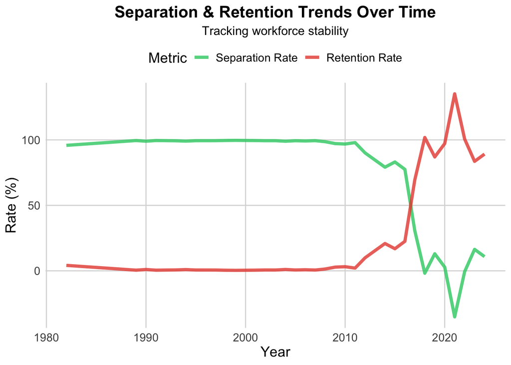

```r
# Convert to long format for ggplot
separation_trends_long <- separation_trends %>%
  pivot_longer(cols = c(separation_rate, retention_rate),
               names_to = "metric",
               values_to = "rate")

# Define custom colors
custom_colors <- c("separation_rate" = "#E74C3C",  # Red for separation
                   "retention_rate" = "#2ECC71")   # Green for retention

# Create a visually appealing line graph
ggplot(separation_trends_long, aes(x = year, y = rate, color = metric)) +
  geom_line(size = 1.5, alpha = 0.8) +
  scale_color_manual(values = custom_colors, labels = c("Separation Rate", "Retention Rate")) +
  labs(title = "Separation & Retention Trends Over Time",
       subtitle = "Tracking workforce stability",
       x = "Year",
       y = "Rate (%)",
       color = "Metric") +
  theme_minimal() +
  theme(text = element_text(size = 14),
        plot.title = element_text(face = "bold", size = 16, hjust = 0.5),
        plot.subtitle = element_text(size = 12, hjust = 0.5),
        legend.position = "top",
        panel.grid.major = element_line(color = "gray85"),
        panel.grid.minor = element_blank())
```

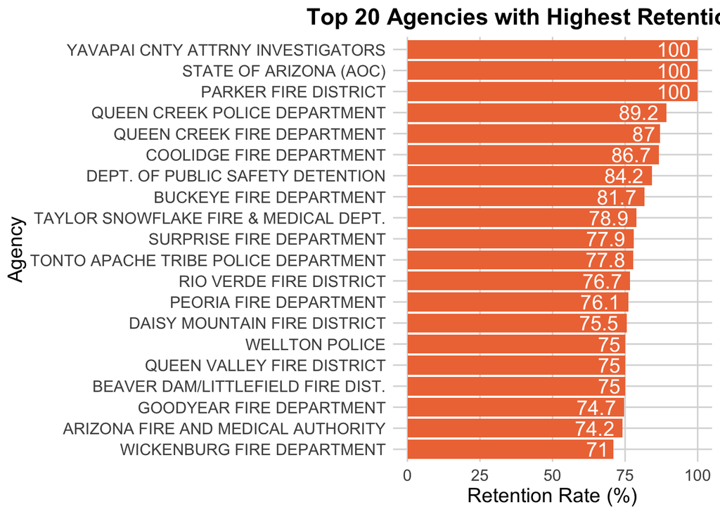

```r
# Calculate retention rate per agency
agency_retention <- df %>%
  group_by(employer_name) %>%
  summarise(separations = sum(!is.na(term_dt)),
            total_employees = n(),
            retention_rate = (1 - (separations / total_employees)) * 100,
            .groups = "drop") %>%
  arrange(desc(retention_rate))

# Select top 20 agencies with highest retention
top_20_retention <- agency_retention %>% top_n(20, retention_rate)

# Create a horizontal bar chart
ggplot(top_20_retention, aes(x = retention_rate, y = reorder(employer_name, retention_rate))) +
  geom_col(fill = "#E74") +  # Green for retention
  geom_text(aes(label = round(retention_rate, 1)), hjust = 1.2, color = "white", size = 5) +  # Add labels
  labs(title = "Top 20 Agencies with Highest Retention Rate",
       x = "Retention Rate (%)",
       y = "Agency") +
  theme_minimal() +
  theme(text = element_text(size = 14),
        plot.title = element_text(face = "bold", size = 16, hjust = 0.5),
        panel.grid.major = element_line(color = "gray85"),
        panel.grid.minor = element_blank())
```

From the chart above, top agencies have consistently high retention rates. This is meaning that employees tend to stay longer in these organizations. The highest-ranked agencies have a perfect retention, while others in the top 20 still maintain strong employee stability. The differences between agencies suggest that some organizations have better long-term employee retention than others. This is could be affected by workplace conditions, policies, or job stability.

RQ1 e.

```r
# Ensure hire and termination dates are in Date format
df <- df %>%
  mutate(hire_dt = as.Date(hire_dt),
         term_dt = as.Date(term_dt),
         hire_year = year(hire_dt),
         term_year = year(term_dt))

# Identify employees who transferred (left one agency and joined another)
transfers <- df %>%
  filter(!is.na(term_dt) & !is.na(hire_dt) & hire_dt > term_dt) %>%
  group_by(hire_year) %>%
  summarise(transfers = n(), .groups = "drop") %>%
  rename(year = hire_year)

# Count total employees per year
total_employees <- df %>%
  group_by(hire_year) %>%
  summarise(total_employees = n(), .groups = "drop") %>%
  rename(year = hire_year)

# Merge datasets and calculate transfer rate
transfer_trends <- left_join(transfers, total_employees, by = "year") %>%
  mutate(transfer_rate = (transfers / total_employees) * 100)
```

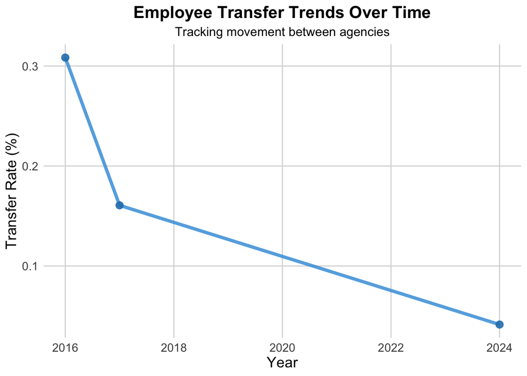

```r
# Create a visually appealing line graph
ggplot(transfer_trends, aes(x = year, y = transfer_rate)) +
  geom_line(size = 1.5, color = "#3498DB", alpha = 0.8) +  # Smooth line (blue)
  geom_point(size = 3, color = "#2980B9", alpha = 0.9) +   # Highlight points
  labs(title = "Employee Transfer Trends Over Time",
       subtitle = "Tracking movement between agencies",
       x = "Year",
       y = "Transfer Rate (%)") +
  theme_minimal() +
  theme(text = element_text(size = 14),
        plot.title = element_text(face = "bold", size = 16, hjust = 0.5),
        plot.subtitle = element_text(size = 12, hjust = 0.5),
        panel.grid.major = element_line(color = "gray85"),
        panel.grid.minor = element_blank())
```

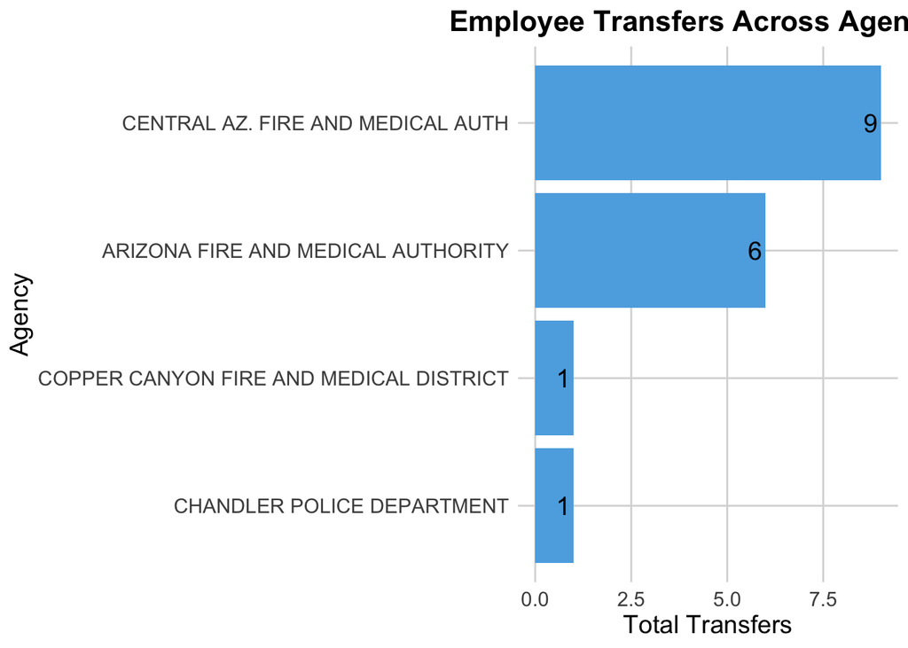

```r
# Count number of employees who transferred into each agency
transfers_by_agency <- df %>%
  filter(!is.na(term_dt) & !is.na(hire_dt) & hire_dt > term_dt) %>%
  group_by(employer_name) %>%
  summarise(total_transfers = n(), .groups = "drop") %>%
  arrange(desc(total_transfers))

# Select top 20 agencies with the highest transfers
top_20_transfers <- transfers_by_agency %>% top_n(20, total_transfers)

# Create a horizontal bar chart
ggplot(top_20_transfers, aes(x = total_transfers, y = reorder(employer_name, total_transfers))) +
  geom_col(fill = "#5DADE2") +
  geom_text(aes(label = total_transfers), hjust = 1.2, color = "black", size = 5) +  # Add labels
  labs(title = "Employee Transfers Across Agencies",
       x = "Total Transfers",
       y = "Agency") +
  theme_minimal() +
  theme(text = element_text(size = 14),
        plot.title = element_text(face = "bold", size = 16, hjust = 0.5),
        panel.grid.major = element_line(color = "gray85"),
        panel.grid.minor = element_blank())
```